# 常用统计检验方法总结

pmgh

2025-08-28

基于R语言，整理统计学中常用的假设检验方法，包括基本原理、目的、适用、R语言代码等。

# 环境设定

```r
# 加载包
library(ggplot2)
library(patchwork)
library(data.table)
library(magrittr)
```

# 1. 数据类型

数据可以分为如下四种测量尺度（Stevens, 1946）：

1. 分类数据：

   1.1 定类数据：类别值、无顺序、数值本身无意义、无法比较、无法运算，例如，1表示男，2表示女

   1.2 定序数据：类别值、有数据、数值本身无意义、可比较、无法运算，例如，第1名、第2名
2. 数值数据：

   2.1 定距数据：数值、可加减、不可乘除、只有相对意义没有绝对意义、没有绝对0点，例如，温度

   2.2 定比数据：数值、可加减乘除、既有相对意义也有绝对意义

# 2. 统计分布

三大统计分布

## 2.1 正态分布

## 2.2 卡方分布

## 2.3 t分布

## 2.4 F分布

统计分布总结

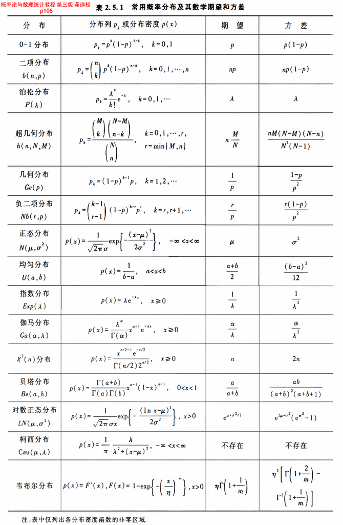

在R语言中，统计分布基本都对应四个函数，例如对于正态分布，四个函数包括：

- dnorm: 概率密度函数PDF，正态分布的概率密度值，自变量是正无穷到负无穷的数x，因变量是x对应的正态分布概率密度，即$P(X=x)$
- pnorm: 累积分布函数CDF，正态分布的累积分布函数值，自变量是正无穷到负无穷的数x，因变量是x在正态分布上的累计概率密度，即$P(X\leq x)$
- qnorm: 分位点函数Quantile，正态分布的分位数，自变量是01区间的概率p，因变量是p的分位数值，即$P(X\leq x)=p$对应的x值，含义是，“在这个分布中，多大的值x，使得小于等于x的概率恰好是p”。本质上，pnorm和qnorm互为反函数
- rnorm: 随机数生成函数，生成满足正态分布的一系列随机数

前三个的函数曲线，以及rnorm生成的随机数（point）如下图所示：

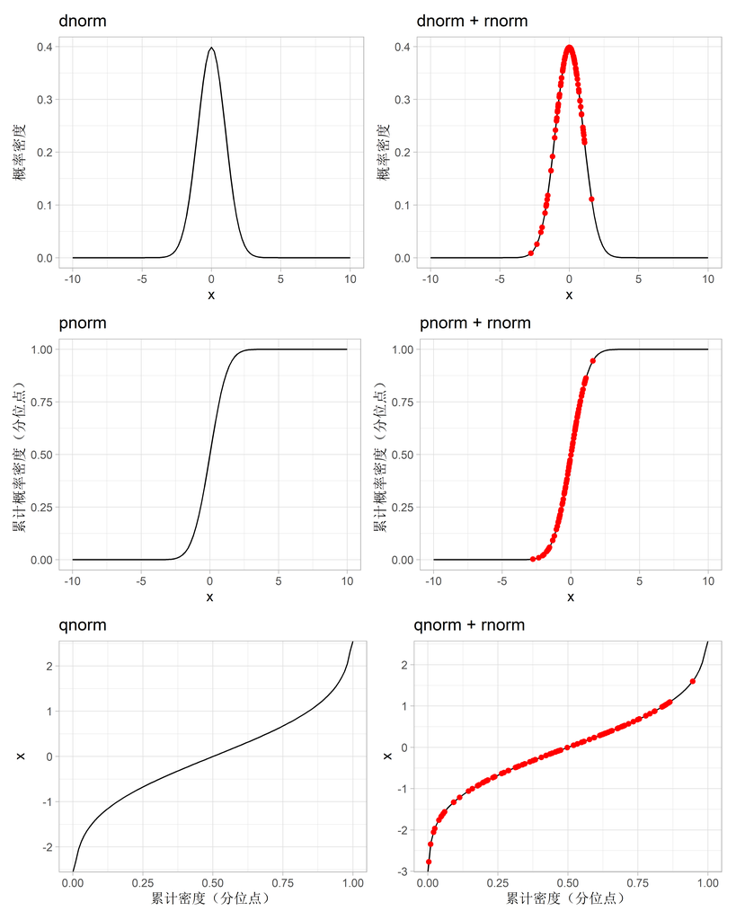

```r
# 散点数据
x <- rnorm(100)
dx <- dnorm(x)
px <- pnorm(x)

# 函数图像
p1 <- ggplot()+
  geom_function(fun=dnorm)+
  scale_x_continuous(limits = c(-10,10))+
  labs(x="x", y="概率密度", title="dnorm")+
  theme_light()
p2 <- ggplot()+
  geom_function(fun=dnorm)+
  annotate("point", x=x, y=dx, color="red")+
  scale_x_continuous(limits = c(-10,10))+
  labs(x="x", y="概率密度", title="dnorm + rnorm")+
  theme_light()
p3 <- ggplot()+
  geom_function(fun=pnorm)+
  scale_x_continuous(limits = c(-10,10))+
  labs(x="x", y="累计概率密度（分位点）", title="pnorm")+
  theme_light()
p4 <- ggplot()+
  geom_function(fun=pnorm)+
  annotate("point", x=x, y=px, color="red")+
  scale_x_continuous(limits = c(-10,10))+
  labs(x="x", y="累计概率密度（分位点）", title="pnorm + rnorm")+
  theme_light()
p5 <- ggplot()+
  geom_function(fun=qnorm)+
  scale_x_continuous(limits = c(0,1))+
  labs(x="累计密度（分位点）", y="x", title="qnorm")+
  theme_light()
p6 <- ggplot()+
  geom_function(fun=qnorm)+
  annotate("point", x=px, y=x, color="red")+
  scale_x_continuous(limits = c(0,1))+
  labs(x="累计密度（分位点）", y="x", title="qnorm + rnorm")+
  theme_light()

# 合并
(p1 + p2) / (p3 + p4) / (p5 + p6)
```

R语言中的分布函数，主要有以下几种（以r*函数为利）

**连续分布**

| 分布名 | 随机数生成函数 | 描述 |
| --- | --- | --- |
| 正态分布 | `rnorm()` | 常见自然现象的分布 |
| 均匀分布 | `runif()` | 所有值等概率 |
| t分布 | `rt()` | 小样本估计均值差异时常用 |
| F分布 | `rf()` | 方差分析中常用 |
| 卡方分布 | `rchisq()` | 检验统计量的分布之一 |
| 指数分布 | `rexp()` | 表示事件发生的等待时间 |
| 伽马分布 | `rgamma()` | 等待多个事件的时间 |
| beta分布 | `rbeta()` | 定义在 [0,1] 区间的概率 |
| 对数正态分布 | `rlnorm()` | 对数符合正态的分布 |
| Cauchy分布 | `rcauchy()` | 重尾分布 |
| Weibull分布 | `rweibull()` | 寿命分析常用 |
| logistic分布 | `rlogis()` | 比正态分布胖尾 |
| Pareto分布 | `VGAM::rpareto()` | 少数占多数的分布，如财富等 |

**离散分布**

| 分布名 | 随机数生成函数 | 描述 |
| --- | --- | --- |
| 二项分布 | `rbinom()` | 成功/失败的次数 |
| 泊松分布 | `rpois()` | 单位时间内事件次数 |
| 几何分布 | `rgeom()` | 第一次成功前的失败次数 |
| 负二项分布 | `rnbinom()` | 成功r次前的失败次数 |
| 超几何分布 | `rhyper()` | 抽卡问题/不放回抽样 |
| 多项分布 | `rmultinom()` | 多类事件的分布 |

# 3. 基础统计量

常用统计量和计算方法包括：

**集中趋势**

- 均值：`mean(x)`
- 中位数：`median(x)`
- 众数：`DescTools::Mode(x)`

**离散程度**

- 极差：`diff(range(x))`，最大值与最小值之差
- 四分位差：`IQR(x)`，第3四分位数 - 第1四分位数
- 方差：`var(x)`
- 标准差：`sd(x)`
- 标准误：`sd(x)/sqrt(n)`
- 变异系数：`sd(x)/mean(x)`

**分布形态**

- 偏度：`e1071::skewness()`，分布的对称性（偏左或偏右）
- 峰度：`e1071::kurtosis()`，分布的“尖峭”程度（比正态分布更尖或更平）

**位置指标**

- 最值：`min(x)`, `max(x)`
- 百分位数：`quantile(x)`, `quantile(x, 0.3)`，默认5个分位数，或者自定义哪个分位数

**统计量工具**

- `summary(x)`，返回最小值、一三分位数、均值、中位数、最大值
- `psych::describe(x)`，返回多种描述统计量指标
- `pastecs::stat.desc(x)`，返回多种描述统计量指标
- `skimr::skim(x)`，返回多种描述统计量指标

**注意**

在R语言中，均值都是除以n，而方差、标准差都是样本统计量，即除以(n-1)

# 4. 统计检验类型

概述统计检验有哪些类别，以及其中包含哪些检验，而检验的具体细节，见第5节。

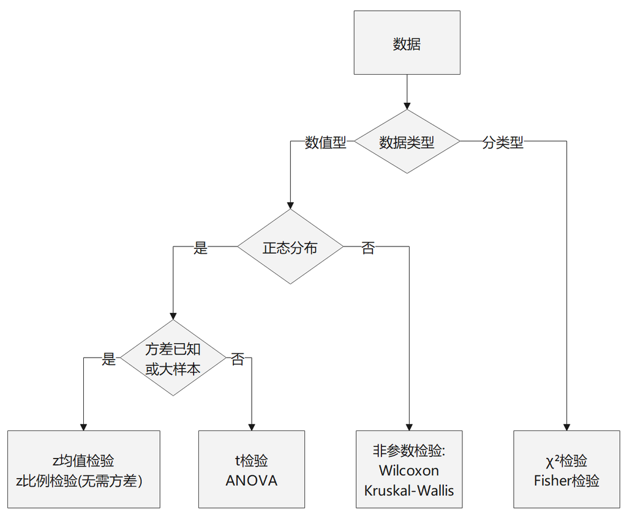

# 5. 统计检验方法

介绍常用统计检验方法的目的、适用性、计算公式、结果判定、案例（R语言方法）

**注意**

1. 统计检验的判定标准，主要有以下几种，因此对于假设检验结果判定，除了统计量，最重要的是计算p值和拒绝域临界值：
   - p值 + 显著性水平α： 若$p \leq \alpha$，则拒绝H0
   - 统计量 + 拒绝域： 若统计量落在拒绝域内，则拒绝H0
   - 数据 + 置信区间CI： 若数据落在CI内，则不拒绝H0（不常用）
2. 对于p值和α，可以理解为分别是统计量和拒绝域的累计概率（在密度函数中体现为下围面积），因此如果$p \leq \alpha$，说明统计量的面积比α的还小，因此统计量必然落在拒绝域内。或者将p值理解为一种显著性水平，并且是“能拒绝原假设的最小显著性水平”，如果显著性水平更小的话就不能拒绝原假设了，因此比p大的α可以拒绝原假设，比p小的α不能拒绝原假设。
3. 对于p值、拒绝域（或CI）的计算，与原假设和备择假设、统计分布特征有关。而根据定义，拒绝域（拒绝H0）的方向和H0的方向相反、和H1的方向相同：
   - 若H0是=，则H1是≠，拒绝域在两侧。若统计分布中心对称，则p值是大于等于统计量绝对值的概率的2倍，否则是大于等于统计量概率和小于等于统计量概率中，小的那个的2倍。
   - 若H0是≤，则H1是>，拒绝域在右侧，p值是大于等于统计量的概率。
   - 若H0是≥，则H1是<，拒绝域在左侧，p值是小于等于统计量的概率。
4. 对假设检验的结果，建议使用“拒绝原假设”或“接受原假设”进行评判。“通过检验”的说法并不严谨，因为有些检验我们渴望拒绝原假设（如回归系数t检验的原假设为$\beta=0$），有些时候我们又渴望接受原假设（如Shapiro-Wilk检验的原假设为数据服从正态分布），“通过”暗示检验结果符合意愿，但对于混淆了原假设是什么，也给p值判定方法造成困扰。

## 5.1 z检验

也叫u检验，注意并非U检验（非参数的Mann–Whitney U检验）

**目的**

- 检验单样本：样本均值、比例是否等于总体均值、比例
- 检验两独立样本：均值、比例是否相等

**适用**

- 检验类型：参数检验（需假设数据服从正态分布，且方差已知）
- 数据类型：数值数据（连续型）
- 数据体量：大样本（通常n≥30，或np≥10且n(1-p)≥10，或小样本但总体方差已知）

注意：

- z检验最为理想化，总体方差（或标准差）已知的条件太过苛刻，实际中，当样本量足够大时，将样本方差近似为总体方差时，才可用，一般情况可使用t检验替代。
- 比例数据实际上是二项分布，当np和n(1-p)较大时，二项分布的抽样趋近于正态分布，因此大样本下可以用z比例检验，也因此，小样本情况下比例数据的t检验就不适用了。

**计算公式**

1. 单样本均值z检验：
   $$z=\frac{\bar X -
   \mu_0}{\sigma / \sqrt n}$$
2. 单样本比例z检验：
   $$z=\frac{\hat p -
   p_0}{\sqrt{p_0(1-p_0)/n}}$$
3. 两独立样本均值z检验：
   $$z=\frac{\bar
   X_1 - \bar X_2}{\sqrt{\sigma^2_1/n_1 +
   \sigma^2_2/n_2}}$$
4. 两独立样本比例z检验：
   $$z=\frac{\hat
   p_1 - \hat p_2}{\sqrt{\hat p_p(1-\hat p_p)(1/n_1+1/n_2)}}, 其中\hat
   p_p=\frac{\hat p_1n_1+\hat p_2n_2}{n_1+n_2}$$
5. 单样本配对均值z检验，技术上可以，但理论上，配对差异的总体标准差不可能已知，因此建议用t检验。

上式中的符号含义如下：

- 样本的：$\bar X$，样本均值；$n$样本数量；$\hat p$，样本比例。
- 总体的：$\mu_0$，总体均值；$\sigma$，总体标准差；$p_0$，总体比例。

**结果判定**

统计量z服从标准正态分布，该分布关于0点左右对称。设定显著性水平为α后，检验结果判定步骤如下：

1. 若H0为=，则双侧检验，$p=2P(X \geq |z|)$，拒绝域为$|z| \geq z_{1-\alpha/2}$ （由于对称，只取右侧）
2. 若H0为≤，则右侧检验，$p=P(X \geq z)$，拒绝域为$z \geq z_{1-\alpha}$
3. 若H0为≥，则左侧检验，$p=P(X \leq z)$，拒绝域为$z \leq z_{\alpha}$

注意：

1. z服从标准正态分布，密度函数关于X=0左右对称，因此，$|z|$位于密度函数x轴的右侧
2. $z_{\alpha}$表示自左至右累计密度为$\alpha$时对应的$z$值，即等式$\alpha=P(X\leq z)$的解。由于设定的$\alpha$不超过0.5，因此，$z_{\alpha}$位于密度函数x轴的左侧，与$z_{1-\alpha}$关于x=0对称，$z_{1-\alpha/2}$位于右侧，大于$z_{1-\alpha/2}$的面积乘以2等于$\alpha$
3. 一个结果判定的例子：经计算$z=2.12$，另$\alpha = 0.05$，此时：
   - 若H0为=，用双侧检验：p值为$p=2P(X \geq |2.12|)=0.034$，p值在R语言中可用`2*(1-pnorm(2.12))`或`2*(pnorm(-2.12))`计算得出。拒绝域临界值为$z_{1-\alpha /2}$，对应公式为$P(X \geq z_{1-\alpha/2}) = 0.025$，可根据R语言`qnorm(1-0.05/2)`得出$z_{0.975}=1.960$。因此，可根据0.034<0.05或2.12>1.960，拒绝H0，认为≠。
   - 若H0为≤，用右侧检验：p值为$p=P(X \geq 2.12)=0.017$（即`1-pnorm(2.12)`），临界值为$z_{1-\alpha} = z_{0.95}=1.645$（即`qnorm(1-0.05)`）。因此拒绝H0，认为＞。
   - 若H0为≥，用左侧检验：p值为$p=P(X \leq 2.12)=0.983$（即`pnorm(2.12)`），临界值为$z_{\alpha} = z_{0.05}=-1.645$（即`qnorm(0.05)`）。因此不拒绝H0，认为≥。
4. 上述判断过程如下图：

[figure not shown]

**案例**

z检验只有理论价值，实际不常用，此处案例较为简单，并没有使用检验函数，都是手算的。

1. 单样本均值检验

已知某品牌灯泡寿命的总体均值为1000小时，标准差100小时。为检测质量抽取50个，测的平均寿命为990小时，问是否宣传造假。

计算步骤如下（z计算公式：$z=\frac{\bar X - \mu_0}{\sigma / \sqrt n}$）：

```r
# 定义H0：样本均值大于等于总体均值，H1：样本均值小于总体均值，因此用左侧检验

# 设定显著性水平α=0.05
a <- 0.05

# 计算z统计量
z <- (990-1000)/(100/sqrt(50)) #z = -0.7071068

# 定义α=0.05，则对应单（左）侧判定参数：
a <- 0.05
za <- qnorm(0.05)            #zα = -1.644854
p <- pnorm(z)                #p =  0.2397501

# 结论
# 由于z = -0.7071068 > za = -1.644854  （左侧检验）
# 由于p = 0.2397501 > α = 0.05         （p检验不分左右）
# 因此不能决绝H0，接受H0，认为样本均值大于等于总体均值，即没有造假
```

2. 单样本比例z检验：

某电商宣称订单取消率为5%，现观测500个订单，取消率为6.5%，检验是订单取消率否显著增加。

计算步骤如下（z计算公式：$z=\frac{\hat p - p_0}{\sqrt{p_0(1-p_0)/n}}$）：

```r
# 定义H0：取消率减少或没变，H1：取消率增加了，用右侧检验

# 设定显著性水平α=0.05
a <- 0.05

# 计算统计量
z <- (0.065-0.05)/sqrt(0.05*(1-0.05)/500) #z = 1.538968

# 定义α=0.05，则对应单（右）侧判定参数：
a <- 0.05
z1a <- qnorm(1-0.05)        #z1α = 1.644854    #对右侧检验，qnorm是pnorm的逆，1-0.05才是右侧面积
p <- 1-pnorm(z)             #p =  0.06190611  #对右侧检验，pnorm是累计概率，1-pnorm才是右侧面积

# 结论
# 由于z = 1.538968 < z1a = 1.644854  （右侧检验）
# 由于p = 0.06190611 > α = 0.05     （p检验不分左右）
# 因此不能决绝H0，接受H0，认为订单取消量没有显著增加
```

3. 两独立样本均值z检验

计算步骤如下（z计算公式：$z=\frac{\bar X_1 - \bar X_2}{\sqrt{\sigma^2_1/n_1 + \sigma^2_2/n_2}}$）：

```r
# 定义H0：性能相同，H1：性能不同，用双侧检验

# 设定显著性水平α=0.05
a <- 0.05

# 计算统计量
z <- (50-48)/sqrt(2^2/40+3^2/50) #z = 3.779645

# 定义α=0.05，则双侧判定参数：
a <- 0.05
z1a2 <- qnorm(1-0.05/2)         #z1α2 = 1.959964    #双侧检验即是右侧α除以2
p <- (1-pnorm(abs(z)))*2        #p =  0.0001570523 #这里要注意z的符号，双侧最好取绝对值

# 结论
# 由于z = 3.779645 > z1a2 = 1.959964    （双侧检验，取右侧进行判断）
# 由于p = 0.0001570523 < α = 0.05       （p检验不分左右）
# 因此决绝H0，接受H1，认为两厂产品新能不同
```

4. 两独立样本比例z检验

对A产品广告，抽取500次点击率为12%，B产品广告抽取500次点击率为8%，判断两广告点击率是否有区别

计算步骤如下（z计算公式：$z=\frac{\hat p_1 - \hat p_2}{\sqrt{\hat p_p(1-\hat p_p)(1/n_1+1/n_2)}}, 其中\hat p_p=\frac{\hat p_1n_1+\hat p_2n_2}{n_1+n_2}$）：

```r
# 定义H0：点击率相同，H1：点击率不同，用双侧检验

# 设定显著性水平α=0.05
a <- 0.05

# 计算统计量
pp <- (0.12*500+0.08*500)/(500+500)
z <- (0.12-0.08)/sqrt(pp*(1-pp)*(1/500+1/500))  #z = 2.108185

# 定义α=0.05，则双侧判定参数：
a <- 0.05
z1a2 <- qnorm(1-0.05/2)         #z1α2 = 1.959964    #双侧检验即是右侧除以2
p <- (1-pnorm(abs(z)))*2        #p =  0.03501498    #这里要注意z的符号，双侧最好取绝对值

# 结论
# 由于z = 2.108185 > z1a2 = 1.959964      （双侧检验，取右侧进行判断）
# 由于p = 0.03501498 < a = 0.05           （p检验不分左右）
# 因此决绝H0，接受H1，认为广告点击率不同
```